# Marcos de cambio climático en medios noticiosos el Golfo de California

Hem Nalini Morzaria-Luna. CEDO Intercultural Gabriela Cruz-Piñón. Departamento de Ciencias Marinas y Costeras. Universidad Autónoma de Baja California Sur. Andrea K. Gerlak. School of Geography and Development. Associate Research Professor Luis E. Calderón-Aguilera. Departamento de Ecología Marina. Centro de Investigación Científica y de Educación Superior de Ensenada Peggy Turk-Boyer. CEDO Intercultural

Como el cambio climático es enmarcado o presentado puede afectar la respuesta a cambios en condiciones locales y la aceptación de políticas de adaptación. Los medios noticiosos pueden influir en la interpretación que los pescadores tienen del cambio climático al legitimar perspectivas específicas ideológicas o de política pública, al atribuir responsabilidad, comunicar incertidumbre científica y enfatizar el papel de instituciones locales.

Estamos analizando cómo los medios nacionales, regionales y locales comunican el cambio climático en la región que rodea el Golfo de California. Nos enfocamos en medios que tienen presencia en internet únicamente y ambas electrónica e impresa.

We developed a database of all news articles published by local and regional newspapers in the states that border the Gulf of California, Sonora, Sinaloa, Nayarit, Jalisco, Baja California, and Baja California Sur between 01/01/2016 and 12/31/2017 that are archived online, as well as National newspapers that are distributed in the region. Extrajimos articulos basados en las palabras claves “cambio climatico”“,”acidificación del océano”, “Acuerdo de París” (Paris accord), y “protocolo de Kyoto” (Kyoto protocol)

Este es un análisis preliminar con ~1700 artículos de una muestra de 5 fuentes noticiosas locales, regionales, y nacionales, aplicado a artículos publicados entre 2016-2017. En el análisis final incluiremos un número mayor de fuentes noticiosas y más años.

```r
print(head(html.list))
```

| NOMBRE_DEL_PERIODICO | LINK_NOTA | FECHA | ARTICULO |
| --- | --- | --- | --- |
| EL IMPARCIAL | http://www.elimparcial.com/EdicionEnLinea/Notas/VidayEstilo/05122016/1156736-Mitos-sobre-el-cambio-climatico.html | 12/5/2016 | NA |
| EL IMPARCIAL | http://www.elimparcial.com/EdicionEnLinea/Notas/Internacional/16112016/1150405-No-se-revertiran-metas-de-Obama-para-cambio-climatico.html | 11/16/2016 | NA |
| EL IMPARCIAL | http://www.elimparcial.com/EdicionEnLinea/Notas/Internacional/04112016/1146102-Entra-en-vigor-el-Acuerdo-de-Paris-sobre-cambio-climatico.html | 11/4/2016 | NA |
| EL IMPARCIAL | http://www.elimparcial.com/EdicionEnLinea/Notas/CienciayTecnologia/15102016/1139579-Asi-afecta-el-cambio-climatico-a-la-salud.html | 10/15/2016 | NA |
| EL IMPARCIAL | http://www.elimparcial.com/EdicionEnLinea/Notas/Sonora/10102016/1137963-Cambio-climatico-causa-olas-de-calor-Investigador.html | 10/10/2016 | NA |
| EL IMPARCIAL | http://www.elimparcial.com/EdicionEnLinea/Notas/CienciayTecnologia/21092016/1130079-Nueve-cosas-que-despareceran-por-cambio-climatico.html | 9/21/2016 | NA |

```r
print(head(word.tbl))
```

| NOMBRE_DEL_PERIODICO | LINK_NOTA | FECHA | article_num | word | category |
| --- | --- | --- | --- | --- | --- |
| EXPRESO | http://www.expreso.com.mx/seccion/mundo/2643-la-fao-urge-actuar-con-rapidez-ante-cambio-climatico.html | 11/16/2016 | 1 | para | negative |
| EXPRESO | http://www.expreso.com.mx/seccion/mundo/2643-la-fao-urge-actuar-con-rapidez-ante-cambio-climatico.html | 11/16/2016 | 1 | aspiraciones | positive |
| EXPRESO | http://www.expreso.com.mx/seccion/mundo/2643-la-fao-urge-actuar-con-rapidez-ante-cambio-climatico.html | 11/16/2016 | 1 | general | positive |
| EXPRESO | http://www.expreso.com.mx/seccion/mundo/2643-la-fao-urge-actuar-con-rapidez-ante-cambio-climatico.html | 11/16/2016 | 1 | para | negative |
| EXPRESO | http://www.expreso.com.mx/seccion/mundo/2643-la-fao-urge-actuar-con-rapidez-ante-cambio-climatico.html | 11/16/2016 | 1 | tierra | negative |
| EXPRESO | http://www.expreso.com.mx/seccion/mundo/2643-la-fao-urge-actuar-con-rapidez-ante-cambio-climatico.html | 11/16/2016 | 1 | para | negative |

Análisis de sentimiento

Es el proceso que determina el tono emocional que hay detrás de palabras determinadas, si en general el articulo contiene una opinión positiva o negativa sobre el tema

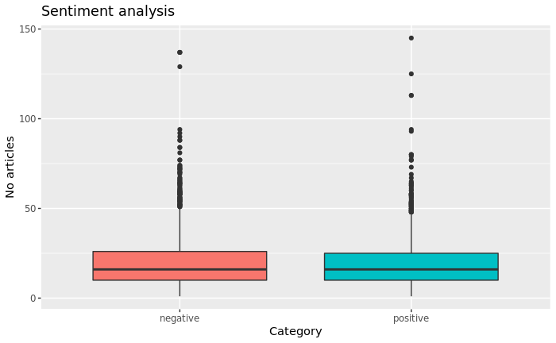

Nube de sentimientos, indica las palabras más comunes con connotación negativa y positiva en el conjunto de fuentes noticiosas.

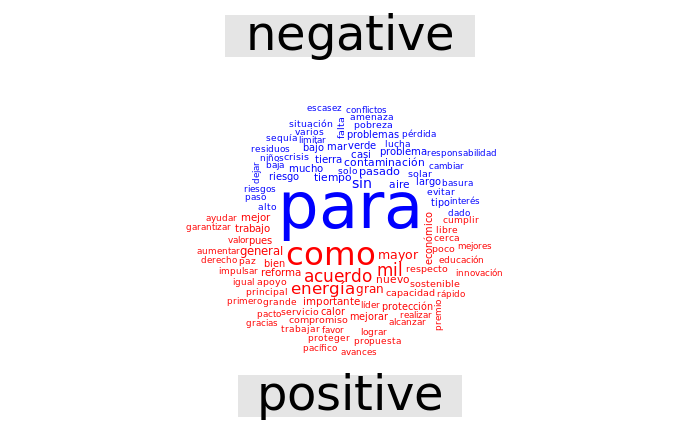

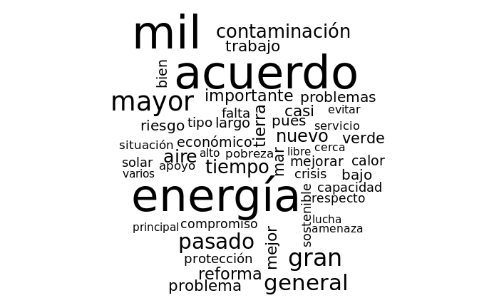

We applied topic modeling, which identifies ‘topics’ or ‘themes’ in the body of the text following the methodology proposed by (Ylä-Anttila et al. 2018). We will use unsupervised machine learning, where we provide no input on how the articles should be classified or apply set pre-interpretations to identify word clusters that can be interpreted as frames, but rather rely on word co-occurrence.

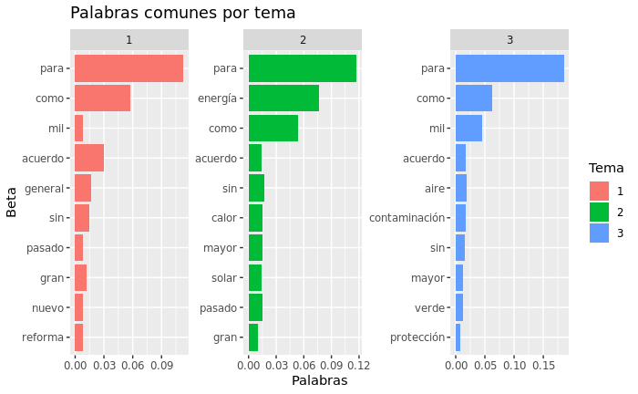

```r
climate.top.terms %>%
  mutate(term=reorder(term, beta)) %>%
  ggplot(aes(term,beta, fill = factor(topic)))+
  geom_col()+
  facet_wrap(~ topic, scales = "free")+
  coord_flip()+
  ggtitle("Palabras comunes por tema") +
  xlab("Beta") +
  ylab("Palabras")+
  labs(fill = "Tema")
```

Esta visualizacion nos permite entender que se extrajeron tres temas del articulo y las palabras mas comunes por tema. Aqui podemos ver que las palabras dominantes son en uno energia, solar, y en otro acuerdo, contaminacion, verde, proteccion.